# Lesson 188 · Systematic literature tracking

## Your tangible win

Build a paper log you can explain and regenerate: **what you searched, what you found, why you kept it, and what remains unverified**. This protects the mission's eventual research claim from stale baselines and attractive but incomparable results. Core reading: 12 minutes; notebook practice: about 25 minutes.

**Observed:** 2/4 query traversals complete; 31 retrieved records → 30 unique papers. Overall quarterly collection **INCOMPLETE**. Frozen-packet replay **COMPLETE**. Seven abstract-screened reading candidates; 23 deferred. Published model-result reproduction **NOT_RUN**. New cloud/API spend **$0**.

[Lesson 178](https://avistian.github.io/relational/lessons/0178-fair-model-comparison.html) showed why model names alone do not define a fair comparison. This lesson moves that discipline earlier: before choosing a paper to implement. [Lesson 187](https://avistian.github.io/relational/lessons/0187-ethics-privacy-reg.html) showed why a performance result cannot establish every claimed guarantee. Apply that same care when screening sources. This prepares [Lesson 189’s draft shortlist](https://avistian.github.io/relational/lessons/0189-identify-open-problems.html); that lesson remains under construction, while [Lesson 190](https://avistian.github.io/relational/lessons/0190-research-gap-checkpoint.html) supplies a worked research checkpoint. The collection log below can be understood independently.

## 1 · Discovery is a measured process

A **query** is an explicit search expression. A **snapshot** is the bytes returned at a recorded time. A **paper identity** groups versions of the same work. A **screening decision** records whether a paper deserves further reading, with a reason. None of these establishes that its model works.

The approved experiment is **L188 Q3-2026 Literature Tracking Replay**. Search July 1 through September 30, 2026, in UTC. Use four separate all-field searches: the exact phrases “relational foundation model” and “tabular foundation model”, plus `RelBench` and `TabArena`. Intersect each with `submittedDate:[202607010000 TO 202609302359]`; order by submission date, ascending. This finds *new submissions* matching these expressions. An older paper revised in September belongs in a separate update queue.

The [arXiv API manual](https://info.arxiv.org/help/api/user-manual.html) documents query expressions, pagination and Atom metadata. **Atom** is a structured XML feed; **pagination** divides a result set into batches. We request 100 records per page and follow the advertised total. These narrow queries can miss synonyms, unindexed text, papers outside arXiv and relevant work that never names either benchmark. Complete pagination means complete *declared-query retrieval*, not a systematic review of the whole field.

Predict: is a first page of 100 out of 203 advertised results a complete search? Explain before continuing.

**Worked trace (synthetic).** A query reports 203 hits. Page offsets 0, 100 and 200 contain 100, 100 and 3 records. The total is stable, offsets are contiguous and all 203 identities are distinct: traversal passes. Delete the middle page and it fails even if both remaining files have valid hashes. A **SHA256 hash** detects changed bytes relative to a trusted manifest; it does not certify the truth of the source.

| Check | Valid trace | Counterexample |
| --- | --- | --- |
| Total | 203 on every page | Changes to 204 mid-fetch |
| Offsets | 0 → 100 → 200 | 0 → 200 |
| Identities | 203 distinct papers | Same paper repeated across pages |
| End | 203 received | Only 200 received |

The collector preserves failed HTTP responses, limits retries and refuses to overwrite an existing packet. An unavailable API is **missing evidence**, not a quarter with zero papers.

## 2 · Keep identity separate from version

Suppose two query responses contain `2607.12345v1` and `2607.12345v2` (synthetic identifiers). Both map to paper identity `2607.12345`; the log retains both version URLs and both query origins. Do not count the second as a new independent paper. Conversely, do not strip arbitrary trailing digits: they are part of the identifier.

Store first-submission date, revision date, retrieval date and exact version separately. The first answers “new this quarter?”; the second “has it changed?”; the third “when did we observe this?”. A response collected today may describe a version updated after the quarter. It cannot by itself establish what readers saw on September 30. The [API manual's version section](https://info.arxiv.org/help/api/user-manual.html#511-a-note-on-article-versions) is the primary reading for this distinction.

**A four-date trace.** Consider a synthetic paper first submitted on July 20, revised as v2 on October 2, and retrieved on October 3. Its v1 and v2 URLs share one identity:

| Question | Answer |
| --- | --- |
| New submission in Q3? | Yes: July 20 |
| Distinct papers? | One identity |
| Version retrieved? | v2, October 3 |
| Q3 content established? | No: need the version available by September 30 |

The submission belongs in the Q3 discovery population, but its newly observed v2 claims cannot automatically be attributed to Q3. Preserve version-specific evidence alongside the identity rather than choosing one date to stand for all four questions.

**Transfer the trace.** Move the first submission to June 20 while retaining a September revision. It leaves this new-submission population and enters the revision queue. Then mark its abstract reviewed with a documented baseline rationale: `triage` may admit it to an appropriate reading queue, but `INCLUDE` still does not change reported evidence into reproduced evidence. The Q3-new-submission queue must retain its own date rule.

Your notebook implements the identity rule rather than hiding it inside a search library.

## 3 · Admit a reading candidate; preserve its evidence level

The course currency rule has three alternative relevance reasons: a reported best result worth checking, a failure mode the thesis must address, or a baseline a fair comparison needs. “Alternative” matters: a useful failure analysis need not also lead a leaderboard. Application-only and incremental variants normally stay out. Use **DEFER** when verification or the reading needed for a decision is missing.

Try a verified baseline candidate; now remove source verification. Should INCLUDE become DEFER? The notebook implements this rule.

| Primary source | Reading decision | Next evidence needed |
| --- | --- | --- |
| [A JEPA Recipe for Tabular Foundation Models](https://arxiv.org/abs/2609.25541) (2026-09-22) | INCLUDE: failure mode | The abstract reports an unfavorable latent-objective comparison and one run per arm. Read training-budget and dataset-identity details before generalizing. |
| [Do Tabular Foundation Models Know Physics? Contamination, Units, and the Deterministic Limit](https://arxiv.org/abs/2609.02766) (2026-09-02) | INCLUDE: failure mode | The abstract raises unit and deterministic-limit failures. Track as a limitation to investigate, not evidence of failure on relational databases. |
| [Xiaomi-TabLDM: A Tabular Foundation Model Technical Report](https://arxiv.org/abs/2609.03880) (2026-09-03) | INCLUDE: baseline | A potential tabular comparator with reported benchmark gains. Check artifacts, fitting budgets and evaluation versions before a matched comparison. |

These entries illustrate decisions, not a comprehensive quarter or an endorsement. A paper title and an abstract do not pin preprocessing, training budgets, data versions, seeds or selection rules. Before promoting a candidate to core, record those details and the executable experiment that would test the relevant claim.

## 4 · A leaderboard is another source with a protocol

Use the official [RelBench leaderboard](https://star-project.stanford.edu/relbench/leaderboard/) and [TabArena board](https://huggingface.co/spaces/TabArena/leaderboard). Record the task suite, version, metric direction, aggregation, tuning budget and adaptation setting. A rank can change because methods improve, tasks change, or the evaluation policy changes. Do not subtract ranks across incompatible boards.

A dynamic page's HTML shell or repository README is not necessarily its result table. The receipt distinguishes successful HTTP retrieval from verified score extraction. **Our current snapshots do not establish Q3 historical standings.** Two comparable dated score snapshots are needed before reporting a change; without them the change stays `NOT_ESTABLISHED`.

## 5 · Make the habit cheap enough to keep

1. **Subscribe locally.** Import the supplied [OPML feed list](https://avistian.github.io/relational/labs/evidence/l188/alerts.opml) into your RSS reader. OPML is an interchange file for subscriptions. It contains `cs.LG`, `cs.AI` and `stat.ML` arXiv feeds. Importing is a learner action; no account subscription or recurring job has been activated here. Category feeds are broader than our four search queries. See the [official RSS guide](https://info.arxiv.org/help/rss.html).
2. **Weekly, ten minutes.** Collect into a new dated packet; screen titles/abstracts; keep exclude/defer reasons. Check known version URLs separately for revisions. No alerts is not proof of no new work—check the last successful fetch.
3. **Monthly, one careful reading.** Audit a candidate's methods, code/data and comparison protocol. Record “when it may help / when it may fail”, with a primary-source pointer and an explicit unknown.
4. **Quarterly, one decision.** Reconcile verified candidates with the curriculum and research-problem log. An abstract-only candidate is a reading queue item, not an automatic new core lesson.

The default collector below is frozen to Q3 for this named replay. For a later quarter, make a new config and experiment identity rather than overwriting the approved packet. Preserve old logs so later decisions can be explained.

## 6 · Run the complete approved lane

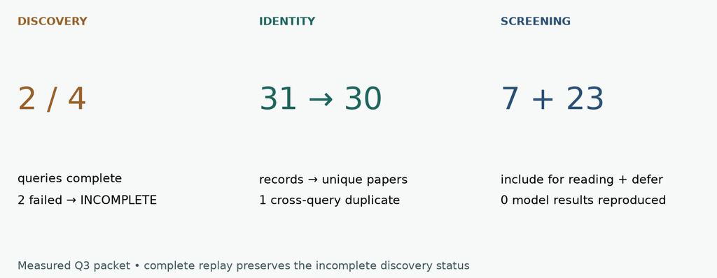

Measured L188 packet: two complete queries, 31 records, 30 unique papers, seven reading candidates and 23 deferred. No model-result reproduction.

| Query | Received / advertised | Coverage |
| --- | --- | --- |
| relational | 0 / unknown | INCOMPLETE |
| tabular | 0 / unknown | INCOMPLETE |
| relbench | 9 / 9 | COMPLETE |
| tabarena | 22 / 22 | COMPLETE |

Four failed API attempts are retained (HTTP 429 or timeout). Zero records from the two failed queries is not a zero-result finding. All 31 successful records were checked independently, yielding 30 unique identities. Seven are admitted for reading and 23 explicitly deferred; all results remain reported, not reproduced. The successful pages each fit within one 100-record request. Synthetic multi-page tests verify pagination behavior separately. [Raw receipt](https://avistian.github.io/relational/labs/evidence/l188/packet/collection.json) · [Independent audit](https://avistian.github.io/relational/labs/_verify_l188_results.json).

**Offline replay:** authenticate every packet file, rebuild all query counts, merge paper identities, and regenerate decisions. The full implementation is visible in the notebook. Its three learner functions control identity, pagination status and admission decisions. Synthetic CHECK cases exercise these contracts even when the live API is unavailable; they never enter the real paper count.

```
.venv/bin/python labs/_budget_l188.py .venv/bin/python labs/_replay_l188.py
.venv/bin/python labs/_budget_l188.py .venv/bin/python labs/_verify_l188.py
```

**Fresh collection:** this command repeats all four frozen queries into a new directory, including failures. It uses the same aggregate budget ledger.

```
.venv/bin/python labs/_budget_l188.py .venv/bin/python labs/_collect_l188.py --output /tmp/l188-new-packet
```

A complete replay of an incomplete packet remains an incomplete collection. No published model result is reproduced by either command.

Open the [student notebook](https://avistian.github.io/relational/labs/0188-systematic-literature-tracking.ipynb), [executed solution](https://avistian.github.io/relational/labs/html/0188-systematic-literature-tracking.html), [paper log](https://avistian.github.io/relational/labs/evidence/l188/paper-log.md), [protocol](https://avistian.github.io/relational/labs/l188-reproduction.md), or [printable reference](https://avistian.github.io/relational/reference/systematic-literature-tracking.html).

## Exit · Defend one inclusion and one unknown

Write the EXIT defense below and ask the teacher to review it.

Submit a 150–250-word note naming the search boundary, one candidate's primary source and relevance, one protocol detail still missing, and the exact next experiment. Explain what would change your inclusion decision. Run all three notebook contracts and attach the regenerated report. Author checks are preparation; your mastery stays `PENDING_WRITTEN_DEFENSE` until you attempt and defend the work.

**Tomorrow:** reconstruct the four dates/identities without looking. **In one week:** screen one new paper and explain whether it changes your proposed baseline. Ask the agent any follow-up question; paste your log entry for feedback on its evidence boundaries.

## PROVIDED · Portable offline bootstrap

This tool/API lab uses real arXiv metadata; CHECK fixtures are explicitly synthetic. No training dataset or model is introduced. The embedded packet contains every collected response, including failures. All replay code uses the Python standard library; no cloud account, repository checkout or network is needed.

```python
# @colab-bootstrap
import base64, hashlib, io, json, tempfile, zipfile
from pathlib import Path
workspace=Path(tempfile.mkdtemp(prefix="l188-replay-"))
```

```python
"""Visible L188 collection/replay contracts. No third-party runtime dependencies."""
import hashlib
import json
import re
import xml.etree.ElementTree as ET
from pathlib import Path
from urllib.parse import urlsplit

ATOM = '{http://www.w3.org/2005/Atom}'
OPEN = '{http://a9.com/-/spec/opensearch/1.1/}'
START = '2026-07-01T00:00:00Z'
END = '2026-10-01T00:00:00Z'
```

## TODO · canonical_id

Validate official arXiv URLs and old/new IDs; group versioned copies without erasing identity digits. Predict a counterexample before writing code.

```python
def canonical_id(value):
    """Validate arXiv identity, then remove a version suffix (not other digits)."""
    value = value.strip()
    if '://' in value:
        u = urlsplit(value)
        if u.scheme not in ('http', 'https') or u.netloc not in ('arxiv.org', 'export.arxiv.org') or u.query or u.fragment:
            raise ValueError('Expected an arXiv identifier or official URL')
        if not u.path.startswith(('/abs/', '/pdf/')):
            raise ValueError('Expected abs/pdf path')
        value = u.path[5:]
    if value.endswith('.pdf'):
        value = value[:-4]
    pattern = r'(?P<base>(?:\d{2}(?:0[1-9]|1[0-2])\.\d{4,5}|[a-z][a-z.-]+/\d{2}(?:0[1-9]|1[0-2])\d{3}))(?:v[1-9]\d*)?'
    m = re.fullmatch(pattern, value)
    if not m:
        raise ValueError('Malformed arXiv identity: ' + value)
    return m['base']
```

### CHECK · Synthetic examples only

```python
assert canonical_id('https://arxiv.org/abs/2607.12345v12')=='2607.12345'
assert canonical_id('hep-th/9901001v2')=='hep-th/9901001'
print('Contract examples passed')
```

```
Contract examples passed
```

## TODO · coverage

Reject missing/overlapping pages, changing totals and repeated identities. A genuine zero-result feed must be present. Predict a counterexample before writing code.

```python
def coverage(pages):
    """A complete traversal has one stable total, contiguous offsets and unique IDs."""
    if not pages or any(p.get('error') for p in pages):
        return 'INCOMPLETE'
    try:
        total = pages[0]['total']
        if type(total) is not int or total < 0:
            return 'INCOMPLETE'
        expected, seen = 0, set()
        for p in sorted(pages, key=lambda p: p['start']):
            if p['total'] != total or p['start'] != expected or (not p['ids'] and total != 0):
                return 'INCOMPLETE'
            ids = [canonical_id(i) for i in p['ids']]
            if len(set(ids)) != len(ids) or seen.intersection(ids):
                return 'INCOMPLETE'
            seen.update(ids)
            expected += len(ids)
        if total == 0 and len(pages) != 1:
            return 'INCOMPLETE'
        return 'COMPLETE' if expected == total else 'INCOMPLETE'
    except (KeyError, TypeError, ValueError):
        return 'INCOMPLETE'
```

### CHECK · Synthetic examples only

```python
assert coverage([{'start':0,'total':3,'ids':['2607.00001','2607.00002']},{'start':2,'total':3,'ids':['2607.00003']}])=='COMPLETE'
assert coverage([{'start':0,'total':3,'ids':['2607.00001','2607.00002']}])=='INCOMPLETE'
assert coverage([])=='INCOMPLETE'
print('Contract examples passed')
```

```
Contract examples passed
```

## TODO · triage

Use verified identity, completed screening, quarter membership, written reason and relevance. Admission does not promote evidence. Predict a counterexample before writing code.

```python
def triage(record):
    """Admission to a reading log is not verification of a scientific result."""
    if not record.get('verified') or not record.get('reviewed') or not record.get('reason', '').strip():
        return 'DEFER'
    if not record.get('in_window'):
        return 'EXCLUDE'
    if record.get('evidence') not in ('reported', 'replayed', 'reproduced'):
        return 'DEFER'
    return 'INCLUDE' if record.get('relevance') in ('sota', 'failure_mode', 'baseline') else 'EXCLUDE'
```

### CHECK · Synthetic examples only

```python
candidate=dict(verified=True,reviewed=True,in_window=True,reason='Required comparator',relevance='baseline',evidence='reported')
assert triage(candidate)=='INCLUDE'
assert triage(dict(candidate,verified=False))=='DEFER'
assert triage(dict(candidate,relevance='incremental'))=='EXCLUDE'
print('Contract examples passed')
```

```
Contract examples passed
```

## PROVIDED · Parse the source bytes

Read the namespace-qualified fields and retain first-submission/revision timestamps. A malformed HTTP200 response must not count as success.

```python
def parse_atom(raw):
    root = ET.fromstring(raw)
    if root.tag != ATOM + 'feed':
        raise ValueError('Not an Atom feed')
    total, start = int(root.findtext(OPEN + 'totalResults')), int(root.findtext(OPEN + 'startIndex'))
    entries = []
    for e in root.findall(ATOM + 'entry'):
        uri = e.findtext(ATOM + 'id')
        identity = canonical_id(uri)
        published, updated = e.findtext(ATOM + 'published'), e.findtext(ATOM + 'updated')
        for date in (published, updated):
            if not date or not re.fullmatch(r'\d{4}-\d{2}-\d{2}T\d{2}:\d{2}:\d{2}Z', date):
                raise ValueError('Unrecognized UTC timestamp')
        entries.append(dict(id=identity, version_uri=uri, title=' '.join(e.findtext(ATOM+'title', '').split()),
                            published=published, updated=updated, summary=' '.join(e.findtext(ATOM+'summary', '').split())))
    return dict(start=start, total=total, ids=[e['id'] for e in entries], entries=entries)
```

## PROVIDED · Replay and review

The pipeline calls your three functions. Source screening is a separate, versioned annotation; raw discovery bytes are unchanged.

```python
def replay(packet, identity_fn=canonical_id, coverage_fn=coverage, triage_fn=triage):
    """Authenticate frozen bytes and regenerate counts using all three learner functions."""
    packet = Path(packet)
    manifest = json.loads((packet/'manifest.json').read_text())
    for name, digest in manifest['files'].items():
        path = (packet/name).resolve()
        if not path.is_relative_to(packet.resolve()) or hashlib.sha256(path.read_bytes()).hexdigest() != digest:
            raise ValueError('Packet hash/path mismatch: ' + name)
    config = json.loads((packet/'config.json').read_text())
    receipt = json.loads((packet/'collection.json').read_text())
    by_id, query_results = {}, {}
    for query in config['queries']:
        pages = []
        for attempt in receipt['attempts']:
            if attempt['kind'] != query['name'] or not attempt.get('accepted'):
                continue
            page = parse_atom((packet/attempt['file']).read_bytes())
            if page['start'] != attempt['start']:
                raise ValueError('Response/request offset mismatch')
            pages.append(page)
            for e in page['entries']:
                k = identity_fn(e['version_uri'])
                row = by_id.setdefault(k, dict(id=k, title=e['title'], published=e['published'], versions=[], queries=[], in_window=START <= e['published'] < END))
                if e['version_uri'] not in row['versions']:row['versions'].append(e['version_uri'])
                if query['name'] not in row['queries']:row['queries'].append(query['name'])
        status = coverage_fn(pages)
        if any(not (START <= e['published'] < END) for p in pages for e in p['entries']):status = 'INCOMPLETE'
        query_results[query['name']] = dict(status=status, pages=len(pages), received=sum(len(p['ids']) for p in pages), total=pages[0]['total'] if pages else None)
    screening = json.loads((packet/'screening.json').read_text())
    records = []
    for k,row in sorted(by_id.items()):
        review = screening.get(k, dict(verified=True, reviewed=False, reason='Awaiting primary-source screening', relevance='unknown', evidence='reported'))
        record = dict(row, **review)
        record['decision'] = triage_fn(record)
        records.append(record)
    return dict(experiment=config['experiment'], window=[START, END],
                collection_status='COMPLETE' if all(q['status']=='COMPLETE' for q in query_results.values()) else 'INCOMPLETE',
                replay_status='COMPLETE', queries=query_results, unique_papers=len(records), papers=records,
                http_attempts=len(receipt['attempts']), failed_attempts=sum(not a.get('ok',False) for a in receipt['attempts']),
                paper_result_reproduction='NOT_RUN', historical_leaderboard='NOT_ESTABLISHED', learner='PENDING_WRITTEN_DEFENSE')

def review_log(report, reviews, triage_fn=triage):
    """Apply separately versioned author screening without altering discovery bytes."""
    known = {r['id'] for r in report['papers']}
    if set(reviews) - known:
        raise ValueError('Review refers to a paper outside this query packet')
    rows = []
    for row in report['papers']:
        annotation = reviews.get(row['id'], dict(reviewed=False, reason='Deferred: full abstract/method screening remains pending.', relevance='unknown', evidence='reported'))
        item = dict(row, **annotation)
        item['decision'] = triage_fn(item)
        rows.append(item)
    return rows
```

## CHECK · Complete real packet

Print the status before interpreting it. All retrieved records are processed; failed queries remain incomplete.

```python
report=replay(packet,canonical_id,coverage,triage)
reviews=json.loads((workspace/'screening-review.json').read_text())
log=review_log(report,reviews,triage)
assert report==json.loads('{"collection_status": "INCOMPLETE", "experiment": "L188 Q3-2026 Literature Tracking Replay", "failed_attempts": 4, "historical_leaderboard": "NOT_ESTABLISHED", "http_attempts": 12, "learner": "PENDING_WRITTEN_DEFENSE", "paper_result_reproduction": "NOT_RUN", "papers": [{"decision": "DEFER", "evidence": "reported", "id": "2607.05103", "in_window": true, "published": "2026-07-06T13:58:19Z", "queries": ["tabarena"], "reason": "Awaiting primary-source screening", "relevance": "unknown", "reviewed": false, "title": "Choosing a parallel heterogeneous ensemble method for tabular classification", "verified": true, "versions": ["http://arxiv.org/abs/2607.05103v1"]}, {"decision": "DEFER", "evidence": "reported", "id": "2607.07089", "in_window": true, "published": "2026-07-08T07:23:09Z", "queries": ["relbench"], "reason": "Awaiting primary-source screening", "relevance": "unknown", "reviewed": false, "title": "Structural Adversarial Attacks on Relational Deep Learning under Integrity Constraints", "verified": true, "versions": ["http://arxiv.org/abs/2607.07089v1"]}, {"decision": "DEFER", "evidence": "reported", "id": "2607.29120", "in_window": true, "published": "2026-07-31T07:50:00Z", "queries": ["relbench"], "reason": "Awaiting primary-source screening", "relevance": "unknown", "reviewed": false, "title": "Curriculum Matters: Data-Efficient Relational PFN Pretraining with Synthetic Data", "verified": true, "versions": ["http://arxiv.org/abs/2607.29120v1"]}, {"decision": "DEFER", "evidence": "reported", "id": "2608.01400", "in_window": true, "published": "2026-08-02T17:33:30Z", "queries": ["tabarena"], "reason": "Awaiting primary-source screening", "relevance": "unknown", "reviewed": false, "title": "TabDPT-Turbo: Efficient In-Context Learning for Tabular Prediction", "verified": true, "versions": ["http://arxiv.org/abs/2608.01400v2"]}, {"decision": "DEFER", "evidence": "reported", "id": "2608.03565", "in_window": true, "published": "2026-08-04T12:29:37Z", "queries": ["tabarena"], "reason": "Awaiting primary-source screening", "relevance": "unknown", "reviewed": false, "title": "Enhancing Tabular Learners with Context-Aware Semantic Embeddings", "verified": true, "versions": ["http://arxiv.org/abs/2608.03565v1"]}, {"decision": "DEFER", "evidence": "reported", "id": "2608.16319", "in_window": true, "published": "2026-08-17T09:25:05Z", "queries": ["relbench", "tabarena"], "reason": "Awaiting primary-source screening", "relevance": "unknown", "reviewed": false, "title": "Advancing Open and Reproducible Relational Learning: RelArena-$\\u03b1$, TabPFN-Rel and RPI", "verified": true, "versions": ["http://arxiv.org/abs/2608.16319v2"]}, {"decision": "DEFER", "evidence": "reported", "id": "2608.16429", "in_window": true, "published": "2026-08-17T11:30:56Z", "queries": ["tabarena"], "reason": "Awaiting primary-source screening", "relevance": "unknown", "reviewed": false, "title": "Localized TabICLv2: Scaling Tabular In-Context Learning through k-NN", "verified": true, "versions": ["http://arxiv.org/abs/2608.16429v1"]}, {"decision": "DEFER", "evidence": "reported", "id": "2608.18849", "in_window": true, "published": "2026-08-19T12:21:02Z", "queries": ["tabarena"], "reason": "Awaiting primary-source screening", "relevance": "unknown", "reviewed": false, "title": "GEAR: Generative Expansion and Real Anchoring for Two-Stage Distillation of Tabular Foundation Models", "verified": true, "versions": ["http://arxiv.org/abs/2608.18849v2"]}, {"decision": "DEFER", "evidence": "reported", "id": "2608.18919", "in_window": true, "published": "2026-08-19T13:51:05Z", "queries": ["tabarena"], "reason": "Awaiting primary-source screening", "relevance": "unknown", "reviewed": false, "title": "Lost in Aggregation: How Benchmarks Overlook Irreplaceable Model Strengths", "verified": true, "versions": ["http://arxiv.org/abs/2608.18919v1"]}, {"decision": "DEFER", "evidence": "reported", "id": "2608.25774", "in_window": true, "published": "2026-08-26T13:17:20Z", "queries": ["tabarena"], "reason": "Awaiting primary-source screening", "relevance": "unknown", "reviewed": false, "title": "EXAONE Tabular 1.0 : Technical Report", "verified": true, "versions": ["http://arxiv.org/abs/2608.25774v1"]}, {"decision": "DEFER", "evidence": "reported", "id": "2608.25903", "in_window": true, "published": "2026-08-26T15:22:52Z", "queries": ["relbench"], "reason": "Awaiting primary-source screening", "relevance": "unknown", "reviewed": false, "title": "MetaSieve: Faster Relational Deep Learning through SQL-Based Metapath Selection", "verified": true, "versions": ["http://arxiv.org/abs/2608.25903v1"]}, {"decision": "DEFER", "evidence": "reported", "id": "2609.00457", "in_window": true, "published": "2026-08-31T22:51:21Z", "queries": ["relbench"], "reason": "Awaiting primary-source screening", "relevance": "unknown", "reviewed": false, "title": "Can LLMs Use Relational Transformer Embeddings?", "verified": true, "versions": ["http://arxiv.org/abs/2609.00457v1"]}, {"decision": "DEFER", "evidence": "reported", "id": "2609.03880", "in_window": true, "published": "2026-09-03T14:06:41Z", "queries": ["tabarena"], "reason": "Awaiting primary-source screening", "relevance": "unknown", "reviewed": false, "title": "Xiaomi-TabLDM: A Tabular Foundation Model Technical Report", "verified": true, "versions": ["http://arxiv.org/abs/2609.03880v2"]}, {"decision": "DEFER", "evidence": "reported", "id": "2609.04540", "in_window": true, "published": "2026-09-03T22:55:05Z", "queries": ["tabarena"], "reason": "Awaiting primary-source screening", "relevance": "unknown", "reviewed": false, "title": "Mitra-v2 Technical Report", "verified": true, "versions": ["http://arxiv.org/abs/2609.04540v1"]}, {"decision": "DEFER", "evidence": "reported", "id": "2609.13031", "in_window": true, "published": "2026-09-11T16:31:29Z", "queries": ["tabarena"], "reason": "Awaiting primary-source screening", "relevance": "unknown", "reviewed": false, "title": "Attention Quantization for Tabular Foundation Models", "verified": true, "versions": ["http://arxiv.org/abs/2609.13031v1"]}, {"decision": "DEFER", "evidence": "reported", "id": "2609.13202", "in_window": true, "published": "2026-08-14T13:21:32Z", "queries": ["tabarena"], "reason": "Awaiting primary-source screening", "relevance": "unknown", "reviewed": false, "title": "Do Tabular Foundation Models Still Need Feature Engineering?", "verified": true, "versions": ["http://arxiv.org/abs/2609.13202v1"]}, {"decision": "DEFER", "evidence": "reported", "id": "2609.16309", "in_window": true, "published": "2026-09-14T20:18:29Z", "queries": ["tabarena"], "reason": "Awaiting primary-source screening", "relevance": "unknown", "reviewed": false, "title": "Agentic Search Spaces for Tabular Machine Learning", "verified": true, "versions": ["http://arxiv.org/abs/2609.16309v1"]}, {"decision": "DEFER", "evidence": "reported", "id": "2609.17488", "in_window": true, "published": "2026-09-15T17:30:02Z", "queries": ["tabarena"], "reason": "Awaiting primary-source screening", "relevance": "unknown", "reviewed": false, "title": "LimiX-2: A Contextual Mechanism Network Towards General Structured-Data Intelligence", "verified": true, "versions": ["http://arxiv.org/abs/2609.17488v1"]}, {"decision": "DEFER", "evidence": "reported", "id": "2609.17895", "in_window": true, "published": "2026-09-15T22:38:29Z", "queries": ["tabarena"], "reason": "Awaiting primary-source screening", "relevance": "unknown", "reviewed": false, "title": "TabPFN-3.5: Technical Report", "verified": true, "versions": ["http://arxiv.org/abs/2609.17895v2"]}, {"decision": "DEFER", "evidence": "reported", "id": "2609.22866", "in_window": true, "published": "2026-09-19T08:09:28Z", "queries": ["tabarena"], "reason": "Awaiting primary-source screening", "relevance": "unknown", "reviewed": false, "title": "Causilo Technical Report", "verified": true, "versions": ["http://arxiv.org/abs/2609.22866v1"]}, {"decision": "DEFER", "evidence": "reported", "id": "2609.26855", "in_window": true, "published": "2026-09-22T14:36:19Z", "queries": ["relbench"], "reason": "Awaiting primary-source screening", "relevance": "unknown", "reviewed": false, "title": "QUARTET: Quad-branch cross-Attention and Random-walk Traces for Enhancing Transformers on Relational Graphs", "verified": true, "versions": ["http://arxiv.org/abs/2609.26855v2"]}, {"decision": "DEFER", "evidence": "reported", "id": "2609.27679", "in_window": true, "published": "2026-09-23T10:54:31Z", "queries": ["tabarena"], "reason": "Awaiting primary-source screening", "relevance": "unknown", "reviewed": false, "title": "What Do Tabular Foundation Models Compute In Context? In-Situ Representation Refinement through Attention-Gated Updates", "verified": true, "versions": ["http://arxiv.org/abs/2609.27679v2"]}, {"decision": "DEFER", "evidence": "reported", "id": "2609.28208", "in_window": true, "published": "2026-09-23T14:45:06Z", "queries": ["tabarena"], "reason": "Awaiting primary-source screening", "relevance": "unknown", "reviewed": false, "title": "Support-Compiled Feature Folding: More Evidence at Lower Memory Across Tabular Foundation Models", "verified": true, "versions": ["http://arxiv.org/abs/2609.28208v2"]}, {"decision": "DEFER", "evidence": "reported", "id": "2609.35219", "in_window": true, "published": "2026-09-28T14:05:37Z", "queries": ["relbench"], "reason": "Awaiting primary-source screening", "relevance": "unknown", "reviewed": false, "title": "Temporal Heterogeneous Graph Pretraining for Relational Deep Learning", "verified": true, "versions": ["http://arxiv.org/abs/2609.35219v1"]}, {"decision": "DEFER", "evidence": "reported", "id": "2609.36108", "in_window": true, "published": "2026-09-28T18:46:48Z", "queries": ["tabarena"], "reason": "Awaiting primary-source screening", "relevance": "unknown", "reviewed": false, "title": "LoopICL: Looping a single transformer block to solve tabular tasks", "verified": true, "versions": ["http://arxiv.org/abs/2609.36108v1"]}, {"decision": "DEFER", "evidence": "reported", "id": "2609.36337", "in_window": true, "published": "2026-09-28T22:17:55Z", "queries": ["tabarena"], "reason": "Awaiting primary-source screening", "relevance": "unknown", "reviewed": false, "title": "Adapting Linear-Time Architectures for Tabular In-Context Learning", "verified": true, "versions": ["http://arxiv.org/abs/2609.36337v1"]}, {"decision": "DEFER", "evidence": "reported", "id": "2609.36384", "in_window": true, "published": "2026-09-28T23:25:04Z", "queries": ["relbench"], "reason": "Awaiting primary-source screening", "relevance": "unknown", "reviewed": false, "title": "Support-Set Target Leakage in Relational Foundation Models during In-Context Learning: Impact, Detection, and Mitigation", "verified": true, "versions": ["http://arxiv.org/abs/2609.36384v1"]}, {"decision": "DEFER", "evidence": "reported", "id": "2609.36417", "in_window": true, "published": "2026-09-29T00:14:48Z", "queries": ["relbench"], "reason": "Awaiting primary-source screening", "relevance": "unknown", "reviewed": false, "title": "Support-Set Target Leakage in Relational Foundation Models during In-Context Learning: Model Dependence and Evaluation Reliability", "verified": true, "versions": ["http://arxiv.org/abs/2609.36417v1"]}, {"decision": "DEFER", "evidence": "reported", "id": "2609.37959", "in_window": true, "published": "2026-09-29T16:30:44Z", "queries": ["tabarena"], "reason": "Awaiting primary-source screening", "relevance": "unknown", "reviewed": false, "title": "TabFM: A Zero-Shot Foundation Model for Tabular Data", "verified": true, "versions": ["http://arxiv.org/abs/2609.37959v1"]}, {"decision": "DEFER", "evidence": "reported", "id": "2609.37989", "in_window": true, "published": "2026-09-29T16:50:56Z", "queries": ["tabarena"], "reason": "Awaiting primary-source screening", "relevance": "unknown", "reviewed": false, "title": "TabFM-Auto: Self-Evolving Pipelines for Tabular Foundation Models", "verified": true, "versions": ["http://arxiv.org/abs/2609.37989v1"]}], "queries": {"relational": {"pages": 0, "received": 0, "status": "INCOMPLETE", "total": null}, "relbench": {"pages": 1, "received": 9, "status": "COMPLETE", "total": 9}, "tabarena": {"pages": 1, "received": 22, "status": "COMPLETE", "total": 22}, "tabular": {"pages": 0, "received": 0, "status": "INCOMPLETE", "total": null}}, "replay_status": "COMPLETE", "unique_papers": 30, "window": ["2026-07-01T00:00:00Z", "2026-10-01T00:00:00Z"]}')
```

```python
assert sum(x['decision']=='INCLUDE' for x in log)==7
assert len(log)==30
Path('l188-report.json').write_text(json.dumps(report,indent=2))
Path('l188-reviewed-log.json').write_text(json.dumps(log,indent=2))
print('Collection:',report['collection_status'],'| Replay:',report['replay_status'])
for name,q in report['queries'].items():
    print(name,q['received'],q['total'],q['status'])
print('Unique papers:',len(log),'| Reading candidates:',sum(x['decision']=='INCLUDE' for x in log))
```

```
Collection: INCOMPLETE | Replay: COMPLETE
relational 0 None INCOMPLETE
tabular 0 None INCOMPLETE
relbench 9 9 COMPLETE
tabarena 22 22 COMPLETE
Unique papers: 30 | Reading candidates: 7
```

## EXIT · Your evidence-backed decision

Write 150–250 words: scope; source; relevance; missing protocol; next experiment. Explain why replay does not repair missing discovery, and why INCLUDE does not mean reproduced. Leave personal mastery pending until the teacher reviews your attempt.

```python
submission={'learner':'PENDING_WRITTEN_DEFENSE','search_boundary':'','candidate_and_source':'','inclusion_reason':'','missing_protocol':'','next_experiment':'','what_would_change_my_mind':''}
Path('l188-submission.json').write_text(json.dumps(submission,indent=2))
```

```
209
```

## NEXT STEP · Fresh collection is separate

Run the repository command in section6 into a new directory. The full collector source is below for inspection. It is not executed in this offline notebook. A fresh result may differ; keep its timestamp, failures and all pages. No recurring task is activated. Paper-result reproduction stays NOT_RUN. Ask the teacher for feedback; revisit after one day and one week.

```
"""Collect a fresh immutable packet. Never overwrites an earlier collection.
Usage: python labs/_collect_l188.py --output /new/packet
"""
import argparse,hashlib,json,time,urllib.request,urllib.error
from datetime import datetime,timezone
from pathlib import Path
from urllib.parse import urlencode
from relkit.literature_l188 import parse_atom,coverage

def main():
    parser=argparse.ArgumentParser();parser.add_argument('--output',required=True);args=parser.parse_args()
    out=Path(args.output);out.mkdir(parents=True,exist_ok=False);(out/'raw').mkdir()
    terms=[('relational','"relational foundation model"'),('tabular','"tabular foundation model"'),('relbench','RelBench'),('tabarena','TabArena')]
    config=dict(experiment='L188 Q3-2026 Literature Tracking Replay',queries=[dict(name=n,search_query=f'all:{q} AND submittedDate:[202607010000 TO 202609302359]') for n,q in terms],page_size=100,sort_by='submittedDate',sort_order='ascending',max_pages=100,max_attempts=2,timeout=30,delay_seconds=3)
    def save(name,obj):(out/name).write_text(json.dumps(obj,indent=2)+'\n')
    save('config.json',config);receipt=dict(attempts=[]);save('screening.json',{})
    last=0
    def fetch(url,kind,start=0):
        nonlocal last
        time.sleep(max(0,3-(time.monotonic()-last)))
        a=dict(url=url,kind=kind,start=start,retrieved_at=datetime.now(timezone.utc).isoformat(),ok=False,accepted=False)
        try:
            req=urllib.request.Request(url,headers={'User-Agent':'RelationalCourse-L188/1.0 (educational reproducibility audit)'})
            with urllib.request.urlopen(req,timeout=30) as r:
                raw=r.read();a.update(status=r.status,final_url=r.url,content_type=r.headers.get('Content-Type',''),ok=r.status==200)
        except urllib.error.HTTPError as exc:raw=exc.read();a.update(status=exc.code,error=str(exc))
        except Exception as exc:raw=b'';a.update(status=None,error=repr(exc))
        last=time.monotonic();name=f'raw/{len(receipt["attempts"]):04d}-{kind}.bin'
        (out/name).write_bytes(raw);a.update(file=name,sha256=hashlib.sha256(raw).hexdigest())
        receipt['attempts'].append(a);save('collection.json',receipt)
        return a,raw
    for query in config['queries']:
        pages=[];offset=0
        for _ in range(config['max_pages']):
            accepted=False
            for attempt in range(config['max_attempts']):
                url='https://export.arxiv.org/api/query?'+urlencode(dict(search_query=query['search_query'],start=offset,max_results=100,sortBy='submittedDate',sortOrder='ascending'))
                a,raw=fetch(url,query['name'],offset)
                if a['ok']:
                    try:
                        p=parse_atom(raw)
                        if p['start']!=offset:raise ValueError('Wrong response offset')
                        pages.append(p);a['accepted']=True;accepted=True
                    except Exception as exc:a.update(ok=False,error='Parse: '+repr(exc))
                save('collection.json',receipt)
                if accepted:break
            if not accepted:break
            if coverage(pages)=='COMPLETE':break
            if not p['ids'] or len({x['total'] for x in pages})!=1:break
            offset+=len(p['ids'])
        print(query['name'],coverage(pages),sum(len(p['ids']) for p in pages),flush=True)
    sources=[('api-manual','https://info.arxiv.org/help/api/user-manual.html'),('api-terms','https://info.arxiv.org/help/api/tou.html'),('rss-guide','https://info.arxiv.org/help/rss.html'),('relbench-board','https://star-project.stanford.edu/relbench/leaderboard/'),('relbench-home','https://star-project.stanford.edu/relbench/'),('tabarena-board','https://huggingface.co/spaces/TabArena/leaderboard/raw/main/README.md')]
    for name,url in sources:
        for _ in range(2):
            a,raw=fetch(url,name)
            if a['ok']:break
    save('manifest.json',dict(files={str(p.relative_to(out)):hashlib.sha256(p.read_bytes()).hexdigest() for p in sorted(out.rglob('*')) if p.is_file()}))
    print('Packet:',out,flush=True)
if __name__=='__main__':main()
```